# Lab 2: Sentiment Analysis I

Melissa Widas

2024-04-10

## Assignment (Due 4/16 by 11:59 PM)

### Obtain your data and load it into R

- Access the Nexis Uni database through the UCSB library: https://www.library.ucsb.edu/research/db/211
- Choose a key search term or terms to define a set of articles.
- Use your search term along with appropriate filters to obtain and download a batch of at least 100 full text search results (.docx). You are limited to downloading 100 articles at a time, so if you have more results than that, you have to download them in batches (rows 1-100, 101-200, 201-300 etc.)

  Guidance for {LexisNexisTools} : https://github.com/JBGruber/LexisNexisTools/wiki/Downloading-Files-From-Nexis
- Read your Nexis article documents into RStudio.
- Use the full text of the articles for the analysis. Inspect the data (in particular the full-text article data).
- If necessary, clean any artifacts of the data collection process (hint: this type of thing should be removed: “Apr 04, 2022( Biofuels Digest: http://www.biofuelsdigest.com/Delivered by Newstex”) and any other urls)
- Remove any clear duplicate articles. LNT has a method for this, but it doesn’t seem to work, so you probably need to do it manually.

### Explore your data and conduct the following analyses:

```r
# load in data
# NEXIS terms were mine reclamation
setwd(here("data/mine_reclamation_files")) #where the .docxs live
mine_files <- list.files(pattern = ".docx", path = getwd(),
                      full.names = TRUE, recursive = TRUE, ignore.case = TRUE)
```

```r
dat_mine <- lnt_read(mine_files, convert_date = FALSE, remove_cover = FALSE)

class(dat_mine)
```

```
## [1] "LNToutput"
## attr(,"package")
## [1] "LexisNexisTools"
```

```r
meta_df <- dat_mine@meta
articles_df <- dat_mine@articles
paragraphs_df <- dat_mine@paragraphs

# examine the columns/delimeters
names(meta_df)
```

```
##  [1] "ID"          "Source_File" "Newspaper"   "Date"        "Length"
##  [6] "Section"     "Author"      "Edition"     "Headline"    "Graphic"
```

```r
names(articles_df)
```

```
## [1] "ID"      "Article"
```

```r
names(paragraphs_df)
```

```
## [1] "Art_ID"    "Par_ID"    "Paragraph"
```

```r
dat2 <- tibble(Date = meta_df$Date, Headline = meta_df$Headline, id = articles_df$ID, text = articles_df$Article)

names(dat2)
```

```
## [1] "Date"     "Headline" "id"       "text"
```

1. Calculate mean sentiment across all your articles
2. Sentiment by article plot. The one provided in class needs significant improvement.

```r
# score the words using bing lexicon
#load the bing sentiment lexicon from tidytext
bing_sent <- get_sentiments("bing")

text_words <- dat2 |>
  unnest_tokens(output = word, input = text, token = "words")

#Let's start with a simple numerical score
sent_words <- text_words |>
  anti_join(stop_words, by = "word") |>
  inner_join(bing_sent, by = "word") |>
  mutate(sent_num = case_when(sentiment == "negative"~-1,
                              sentiment == "positive"~1))

# calculate mean_sentiment (by word polarity) across articles
sent_article <- sent_words |>
  group_by(Headline) |>
  count(id, sentiment) |>
  pivot_wider(names_from = sentiment, values_from = n) |>
  mutate(polarity = positive-negative)

# mean polarity
mean(sent_article$polarity, na.rm=TRUE)
```

```
## [1] 2.8875
```

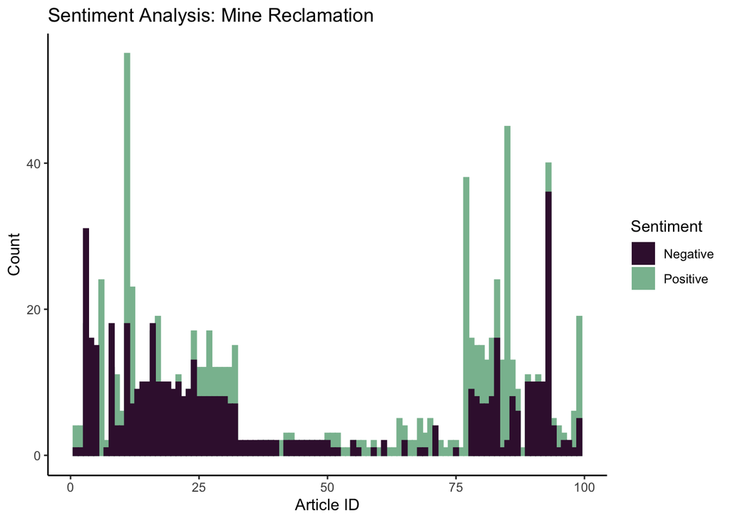

```r
colors <- c("Positive" = "#89BD9E",
            "Negative" = "#3C153B")

fills <- c("Positive" = "#89BD9E",
            "Negative" = "#3C153B")

# sentiment by article plot
ggplot(sent_article, aes(x = id)) +
  theme_classic() +
  geom_col(aes(y = positive, colour = "Positive", fill = "Positive"), position = "identity") +
  geom_col(aes(y = negative, colour = "Negative", fill = "Negative"), position = "identity") +
  labs(title = "Sentiment Analysis: Mine Reclamation", x = "Article ID", y = "Count", fill = "Sentiment") +
  scale_color_manual(values = colors, guide = FALSE) +
  scale_fill_manual(values = fills)
```

3. Most common nrc emotion words and plot by emotion
4. Look at the nrc contribution to emotion by word plots. Identify and reclassify or remove at least one term that gives misleading results in your context.

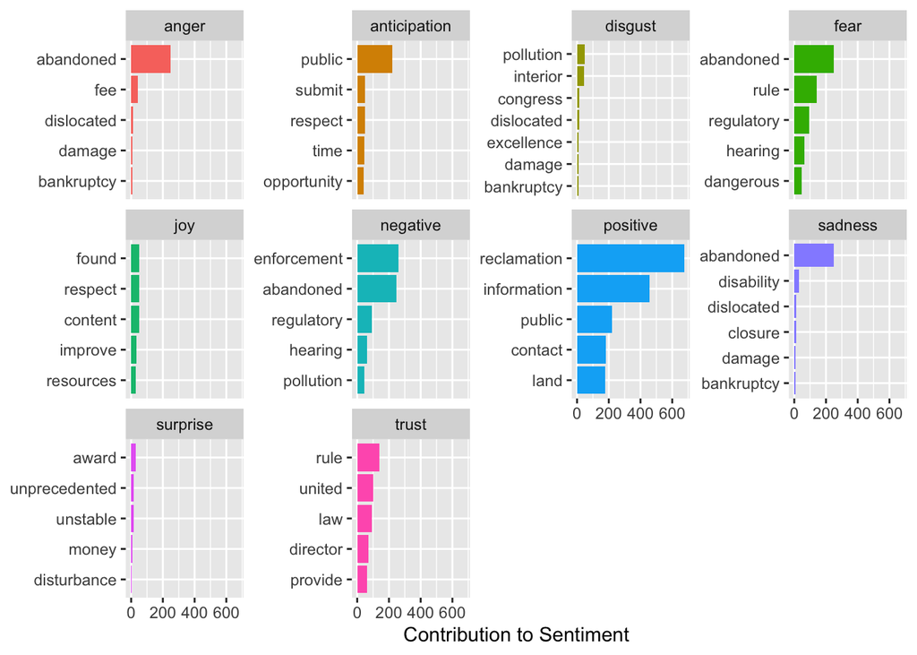

```r
# load nrc sentiments - more than positive and negative
nrc_sent <- get_sentiments("nrc")

nrc_word_counts <- text_words |>
  anti_join(stop_words, by = "word") |>
  inner_join(nrc_sent) |>
  count(word, sentiment, sort = TRUE)

# plot words by sentiment
nrc_word_counts |>
  group_by(sentiment) |>
  # give top 5 words per sentiment
  slice_max(n, n=5) |>
  ungroup() |>
  mutate(word = reorder(word, n)) |>
  ggplot(aes(n,word, fill = sentiment)) +
  geom_col(show.legend = FALSE) +
  facet_wrap(~sentiment, scales="free_y") +
  labs(x = "Contribution to Sentiment", y = NULL)
```

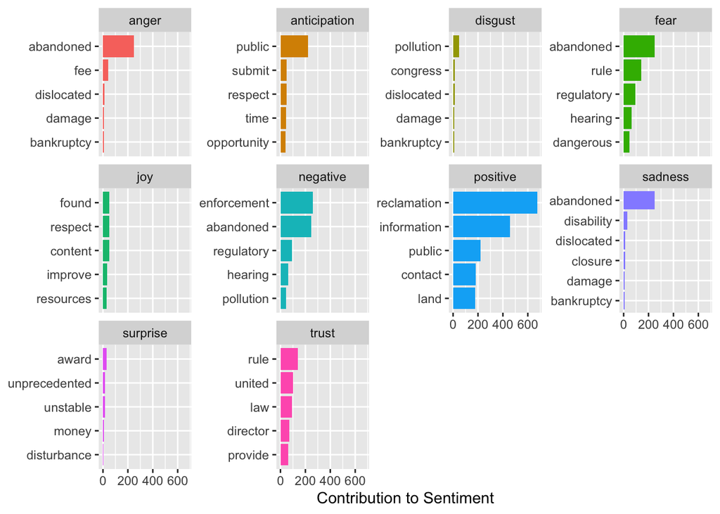

```r
# interior in disgust does not add to the understandability of this sentiment analysis, interior was listed under disgust, positive, and trust
# additionally excellence was listed under disgust
nrc_word_counts_edit <- nrc_word_counts |>
  # remove interior
  filter(word != "interior") |>
  filter(word != "excellence")

# plot words by sentiment with edited word list
nrc_word_counts_edit |>
  group_by(sentiment) |>
  # give top 5 words per sentiment
  slice_max(n, n=5) |>
  ungroup() |>
  mutate(word = reorder(word, n)) |>
  ggplot(aes(n,word, fill = sentiment)) +
  geom_col(show.legend = FALSE) +
  facet_wrap(~sentiment, scales="free_y") +
  labs(x = "Contribution to Sentiment", y = NULL)
```

5. Plot the amount of nrc emotion words as a percentage of all the emotion words used each day (aggregate text from articles published on the same day). How does the distribution of emotion words change over time? Can you think of any reason this would be the case?

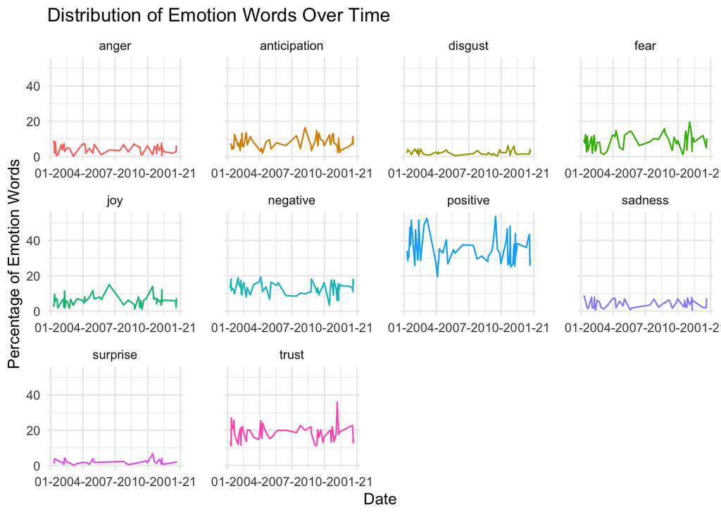

```r
nrc_word_counts_day <- text_words |>
  anti_join(stop_words, by = "word") |>
  inner_join(nrc_sent)  |>
  count(Date, sentiment)

# aggregate the text from articles published on the same day
emotions_per_day <- nrc_word_counts_day %>%
  group_by(Date) %>%
  summarise(total = sum(n))

# calculate the percentage of NRC emotion words per day
emotion_percent <- nrc_word_counts_day |>
  left_join(emotions_per_day, by = "Date") |>
  mutate(percentage = n / total * 100) |>
  mutate(Date = as.Date(Date, format = "%B %d,%y"))

# Plot the distribution of emotion words over time
ggplot(emotion_percent, aes(x = Date, y = percentage, group = sentiment, color = sentiment)) +
  geom_line() +
  theme_minimal() +
  labs(x = "Date", y = "Percentage of Emotion Words", title = "Distribution of Emotion Words Over Time") +
  theme(legend.title = element_blank(), legend.position = "none") +
  scale_x_date(date_labels = "%m-%y") +
  facet_wrap(~sentiment, scales = "free_x") +
  theme(panel.spacing.x = unit(2, "lines"))
```

**The distribution of emotion words does change over time. As different news or events are reposted/occur there will be differenes in the types of stories written. For the most part the emotions seem to oscillate around a consistent percentage however there are some spikes, and dips. For example, joy sees a large spike in July of 2020.**